# Project 4 TC

Overbytes

2022-09-29

# Introduction

The central theme of this project will be to assess the morphological and allometric differences between ecomorphs within the genus Anolis. The term ecomorph describes a group of species, perhaps not sharing a most recent common ancestor, with a similar ecological niche and behavior within the context of this niche. In order to assess the differences between these ecomorphs, we will be conducting the following analyses:

1. Visualize how hind limb length varies with size (i.e., allometry!).
2. Visualize and asses how hind limb length vs. size relationship covary with ecological niche.
3. Learn more complex operations in ggplot than we’ve undertaken so far.
4. Evaluate this hindlimb-size relationship using standard frequentist models within and without a phylogenetic context.
5. Using an information theory approach, assess the fit of phylogenetically corrected models of hind-limb variation under different modes of character evolution.

### Centered image of an *Anolis* lizard

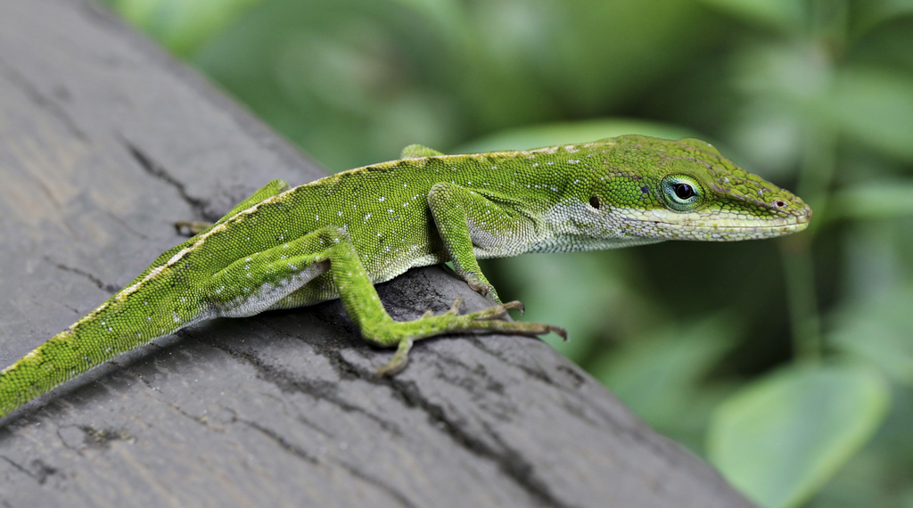

Image of The Anolis Lizard

# Methods

### Loading the data

```r
anole <- read_csv("anole.dat.csv")
anole.eco <- read_csv("anole.eco.csv")
anole.tree <- read.tree("anole.tre")
```

### Cleaning and Merging the Data Sets

```r
anole2 <- anole%>%
left_join(anole.eco)%>%
  filter(!Ecomorph%in%c("U","CH"))%>%
  na.omit()
anole.log <- anole2%>%
  mutate_at(c("SVL", "HTotal","PH","ArbPD"),log)
```

### Creating PGLS Models

```r
### phylogenetic GLS models

#PGLS under BM, no ecomorph
pgls.BM1 <- gls(HTotal ~SVL, correlation = corBrownian(1,phy = anole.tree,form=~Species),data = anole.log, method = "ML")

#PGLS under BM, w ecomorph
pgls.BM2 <- gls(HTotal ~SVL * Ecomorph2, correlation = corBrownian(1,phy = anole.tree,form=~Species),data = anole.log, method = "ML")

#PGLS under OU, no ecomorph
pgls.OU1 <- gls(HTotal ~SVL, correlation = corMartins(0,phy = anole.tree,form=~Species),data = anole.log, method = "ML")

#PGLS under OU, w, ecomorph
pgls.OU2 <- gls(HTotal ~SVL * Ecomorph2, correlation = corMartins(0,phy = anole.tree,form=~Species),data = anole.log, method = "ML")
```

### An altered “AIC” chunk that produces a table of AIC values with kable, a descriptive caption, and row names for data clarication.

```r
#AIC operations
anole.phylo.aic <- AICc(pgls.BM1,pgls.BM2,pgls.OU1,pgls.OU2)
anole.phylow.aicw <- aicw(anole.phylo.aic$AICc)

print(anole.phylow.aicw)
```

```
##         fit     delta            w
## 1 -63.66118 29.319176 4.225281e-07
## 2 -92.98036  0.000000 9.827289e-01
## 3 -57.31864 35.661714 1.772520e-08
## 4 -84.89770  8.082653 1.727062e-02
```

```r
rownames <- rownames(anole.phylow.aicw)
print(rownames)
```

```
## [1] "1" "2" "3" "4"
```

```r
rownames(anole.phylow.aicw) <- c('PGLS under BM and no ecomorph', 'PGLS under BM with ecomorph', 'PGLS under OU with no ecomorph', 'PGLS under OU with ecomorph')

anole.phylow.aicw %>%
  kable(caption = "Comparison of model fits using the Akaike Information Criterion (AIC)")
```

Comparison of model fits using the Akaike Information Criterion (AIC)

|  | fit | delta | w |
| --- | --- | --- | --- |
| PGLS under BM and no ecomorph | -63.66118 | 29.319176 | 0.0000004 |
| PGLS under BM with ecomorph | -92.98036 | 0.000000 | 0.9827289 |
| PGLS under OU with no ecomorph | -57.31864 | 35.661714 | 0.0000000 |
| PGLS under OU with ecomorph | -84.89770 | 8.082653 | 0.0172706 |

### Accounting for Standard Error in Data Through The creation of Residuals

```r
#add phylo-corrected residuals
anole.log <- anole.log%>%
  mutate(phylo.res=residuals(pgls.BM2))
```